# Chap9.5

Mijeong Kim

```r
library(tsibble)
library(tsibbledata)
library(tibble)
library(dplyr)
library(knitr)
library(ggplot2)
library(fpp3)
library(fpp2)
library(seasonal)
library(feasts)
```

## 9.5 Non-seasonal ARIMA models

- **ARIMA**: AutoRegressive Integrated Moving Average
- AR(자기회귀) + I(차분) + MA(이동평균)를 결합한 시계열 예측 모델

#### 일반적인 ARIMA 모델 수식

#### (9.1)

$$y'_t = c + \phi_1 y'_{t-1} + \dots + \phi_p y'_{t-p} +
\theta_1 \varepsilon_{t-1} + \dots + \theta_q \varepsilon_{t-q} +
\varepsilon_t$$

- $y'_t$: 차분된 시계열
- $p$: AR 차수
- $d$: 차분 횟수
- $q$: MA 차수

#### 특수 사례 (Table 9.1)

| 모델 | ARIMA 표현 |
| --- | --- |
| White noise | ARIMA(0,0,0) |
| Random walk | ARIMA(0,1,0) |
| Random walk with drift | ARIMA(0,1,0) + 상수 |
| Autoregression (AR) | ARIMA(p,0,0) |
| Moving Average (MA) | ARIMA(0,0,q) |

### Example: Egyptian exports

Figure 9.7은 1960년부터 2017년까지 이집트 수출이 GDP에서 차지하는 비율을 보여준다.

#### Backshift 표기법으로 표현 (Equation 9.2)

$$(1 - \phi_1 B - \dots - \phi_p B^p)(1 - B)^d y_t = c + (1 + \theta_1 B +
\dots + \theta_q B^q)\varepsilon_t$$

- $B$: 후방 이동 연산자
- 각 항의 의미:
  - **AR($p$)**: 자기회귀 부분
  - **$(1 - B)^d$**: 차분
  - **MA($q$)**: 이동 평균 부분

#### 모델 구성 선택

- $p$, $d$, $q$ 선택은 간단하지 않음
- `fable` 패키지의 **`ARIMA()` 함수**가 자동으로 적절한 값을 선택해 줌

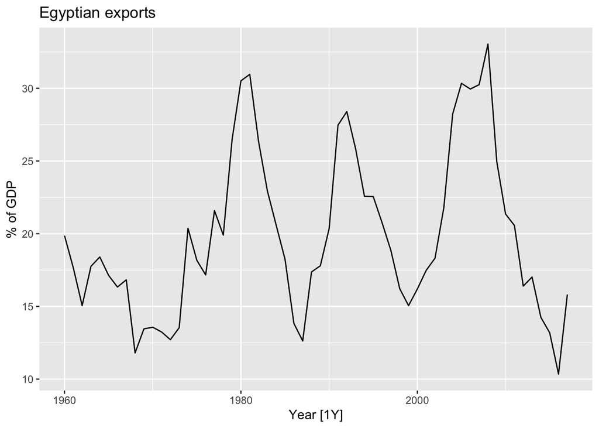

```r
global_economy |>
  filter(Code == "EGY") |>
  autoplot(Exports) +
  labs(y = "% of GDP", title = "Egyptian exports")
```

Figure 9.7: Annual Egyptian exports as a percentage of GDP since 1960.

```r
fit <- global_economy |>
  filter(Code == "EGY") |>
  model(ARIMA(Exports))
report(fit)
```

```
## Series: Exports
## Model: ARIMA(2,0,1) w/ mean
##
## Coefficients:
##          ar1      ar2      ma1  constant
##       1.6764  -0.8034  -0.6896    2.5623
## s.e.  0.1111   0.0928   0.1492    0.1161
##
## sigma^2 estimated as 8.046:  log likelihood=-141.57
## AIC=293.13   AICc=294.29   BIC=303.43
```

#### 적합된 ARIMA 모델

- **모델 형태**: ARIMA(2,0,1)

$$y_t = 2.56 + 1.68 y_{t-1} - 0.80 y_{t-2} - 0.69 \varepsilon_{t-1} +
\varepsilon_t$$

- $\varepsilon_t$: **표준편차 2.837**의 백색잡음  
  (분산: $8.046 \Rightarrow \sqrt{8.046} = 2.837$)

#### 예측 결과

- **Figure 9.8**: 예측치는 과거 수십 년간의 **이집트 경제의 순환적 흐름**을 잘 반영함
- AR(2) 구성 요소 덕분에 **주기적인 변동성** 포착 가능

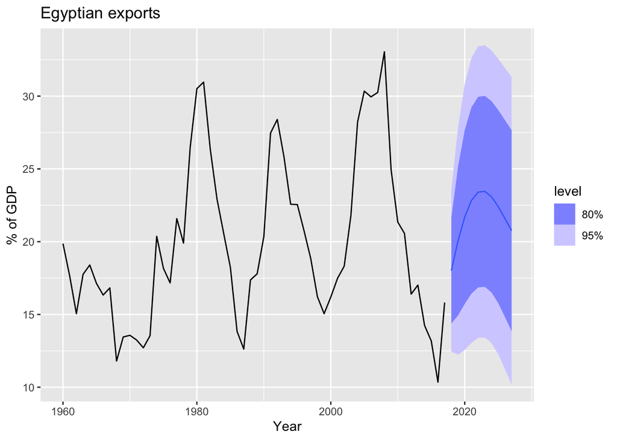

```r
fit |> forecast(h=10) |>
  autoplot(global_economy) +
  labs(y = "% of GDP", title = "Egyptian exports")
```

Figure 9.8: Forecasts of Egyptian exports.

### Understanding ARIMA models

#### 1. 자동 ARIMA 모델 사용 시 주의

- `ARIMA()` 함수는 유용하지만, 모델의 동작을 이해하는 것이 중요함
- 특히 **상수항($c$)**과 **차분 횟수($d$)**는 **장기 예측의 형태**에 큰 영향을 줌

#### 2. 장기 예측 형태 (요약표)

| 조건 | 장기 예측의 형태 |
| --- | --- |
| $c = 0$, $d = 0$ | 0으로 수렴 |
| $c = 0$, $d = 1$ | 일정한 값으로 수렴 |
| $c = 0$, $d = 2$ | 직선 경향 |
| $c \ne 0$, $d = 0$ | 데이터 평균으로 수렴 |
| $c \ne 0$, $d = 1$ | 직선 경향 |
| $c \ne 0$, $d = 2$ | **2차 곡선 경향** (fable에서는 허용하지 않음) |

> $d$가 클수록 **예측 구간이 더 빠르게 넓어짐**

#### 3. 주기성 판단: $p$의 중요성

- **AR(2)** 이상의 모델에서 주기(cycle)를 표현 가능
- 예: **이집트 수출 모델**에서

$$\phi_1^2 + 4\phi_2 < 0$$

→ 이 조건 만족 시 주기성 발생

- 평균 주기:

$$\text{Period} = \frac{2\pi}{\cos^{-1}\left( \frac{-\phi_1(1 -
\phi_2)}{4\phi_2} \right)}$$

### ACF와 PACF

- ACF: 시차 $k$에 따른 **자기상관**
- PACF: 시차 $k$에 대한 **직접적 상관만 측정** (중간 효과 제거)

#### ACF vs PACF 비교

| 내용 | ACF | PACF |
| --- | --- | --- |
| 목적 | 모든 누적 영향 포함 | 순수한 직접 상관 |
| 첫 값 | 동일 | 동일 |
| AR 추정 활용 | 제한적 | 유용함 |
| 모델 판별 | MA 추정에 도움 | AR 추정에 도움 |

#### PACF 계산

- PACF의 $k$번째 계수 $\alpha_k$는 **AR($k$)** 모델의 마지막 계수 $\phi_k$와 동일
- 실제로는 효율적인 알고리즘으로 계산

#### 시각화 예시

- **Figure 9.9**: Egyptian Exports ACF 플롯
- **Figure 9.10**: Egyptian Exports PACF 플롯  
  → 유의 기준선: $\pm \frac{1.96}{\sqrt{T}}$

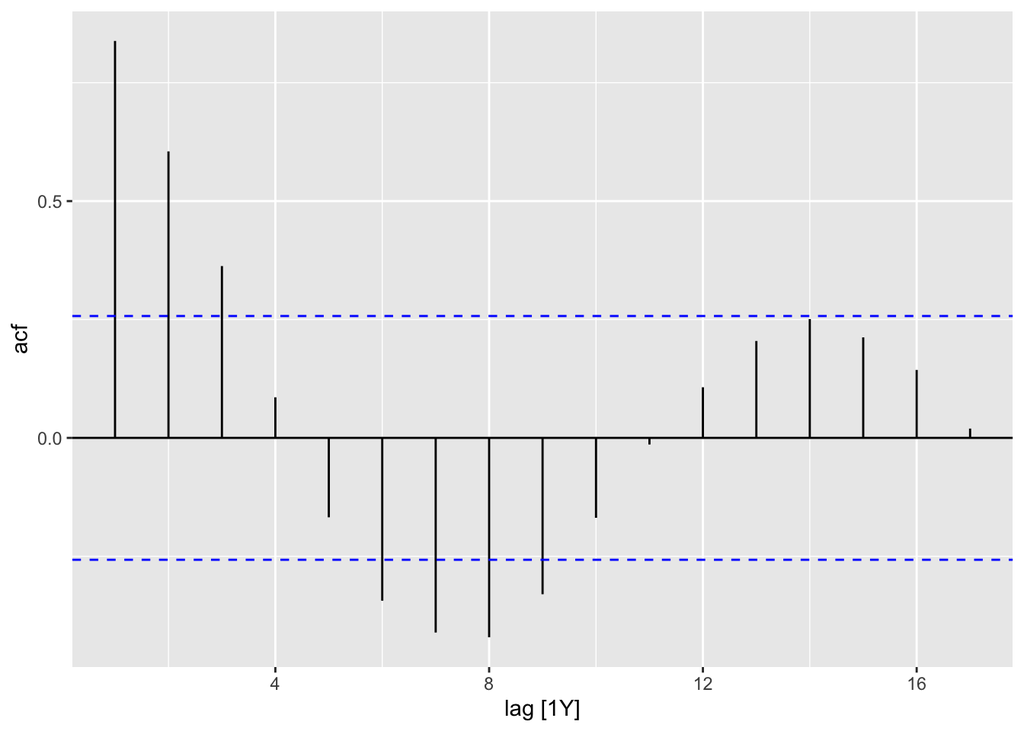

```r
global_economy |>
  filter(Code == "EGY") |>
  ACF(Exports) |>
  autoplot()
```

Figure 9.9: ACF of Egyptian exports.

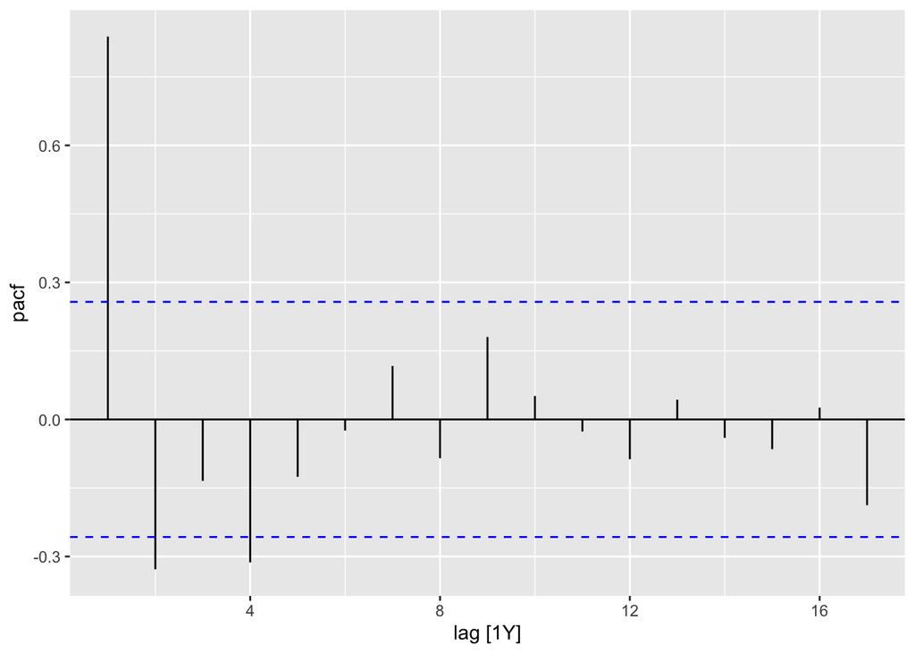

```r
global_economy |>
  filter(Code == "EGY") |>
  PACF(Exports) |>
  autoplot()
```

Figure 9.10: PACF of Egyptian exports.

시계열 그래프, ACF 플롯, PACF 플롯을 한 번에 출력하는 가장 간편한 방법은 plot_type = “partial” 옵션을 사용하여 gg_tsdisplay() 함수를 활용하는 것이다.

- ARIMA(p, d, 0) 또는 ARIMA(0, d, q) 모델일 경우 → ACF와 PACF 플롯은 각각 p 또는 q 값을 결정하는 데 유용함

✅ ARIMA(p, d, 0) 모델일 가능성:

- ACF: 지수 감소 또는 sinusoidal pattern
- PACF: lag p에서 유의한 스파이크, 이후는 유의하지 않음

✅ ARIMA(0, d, q) 모델일 가능성:

- PACF: 지수 감소 또는 sinusoidal pattern

*ACF: lag q에서 유의한 스파이크, 이후는 유의하지 않음

⚠️ 주의: * p와 q가 모두 양수이면, ACF/PACF만으로는 적절한 값 판단 어려움

🔍 예시 (Figure 9.9 & 9.10):

- ACF: decaying sinusoidal pattern
- PACF: lag 4에서 마지막 유의한 스파이크 → → ARIMA(4, 0, 0) 모델에 적합한 패턴

```r
fit2 <- global_economy |>
  filter(Code == "EGY") |>
  model(ARIMA(Exports ~ pdq(4,0,0)))
report(fit2)
```

```
## Series: Exports
## Model: ARIMA(4,0,0) w/ mean
##
## Coefficients:
##          ar1      ar2     ar3      ar4  constant
##       0.9861  -0.1715  0.1807  -0.3283    6.6922
## s.e.  0.1247   0.1865  0.1865   0.1273    0.3562
##
## sigma^2 estimated as 7.885:  log likelihood=-140.53
## AIC=293.05   AICc=294.7   BIC=305.41
```

#### 1. 모델 성능 비교 (AICc 기준)

- `ARIMA(4,0,0)` 모델과 `ARIMA(2,0,1)` 모델 비교
- 두 모델 모두 유사한 성능

| 모델 | AICc 값 |
| --- | --- |
| ARIMA(2,0,1) | **294.29** |
| ARIMA(4,0,0) | 294.70 |

→ `ARIMA(4,0,0)`은 약간 성능이 낮지만, **해석이 명확**할 경우 선택될 수 있음

#### 2. ARIMA 모델 후보 범위 지정: `pdq()`

- `ARIMA()` 함수에 `pdq()`를 사용하면 탐색 범위를 제한할 수 있음

$p \in {1, 2, 3}$, $q \in {0, 1, 2}$, $d = 1$

ARIMA(y ~ pdq(p = 1:3, d = 1, q = 0:2))